# ggplotting_challenge – with code

## Welcome, plotters!

In this challenge, you’ll get the opportunity to plot data from paper by Garcia and colleagues (2015). In it, there is data from 116 Swedish high school students.

For the purposes of this data challenge, we’ll be looking at how **regulatory mode** – as represented by the **locomotion** and **assessment** variables – predicts psychological well-being and academic achievement.

**gender:** Whether students were coded as female (gender==1) or male (gender==2)  
**age:** Age in years.  
**PWB:** This is a “Psychological Well-Being” scale. Higher scores (on a scale of 0-6) indicated higher psychological well-being  
**Locomotion:** This measures a form of “regulatory mode,” and is a personality measure related to goal-directed behavior. High-locomotion people favor taking action over waiting for opportunities to present themselves.  
**Assessment:** This is also a form of “regulatory mode.” High-assessment people place a high value on close observation, data collection, and critical thinking. Importantly, locomotion and assessment are designed to be uncorrelated, so someone can have low scores in both (and be hesitant and inattentive) or high scores in both (and be prone to action and hypervigilant).  
**Excercise:** This is a composite measure of exercise behavior. Higher scores denote a more active student overall.  
**AcademAchieve:** This is a measure of academic achievement using the 20-point scale that is thenorm in Sweden. Thus, this can be thought of as analogous to a GPA.

## First, load ggplot!

```r
require(ggplot2)
```

## Descriptives

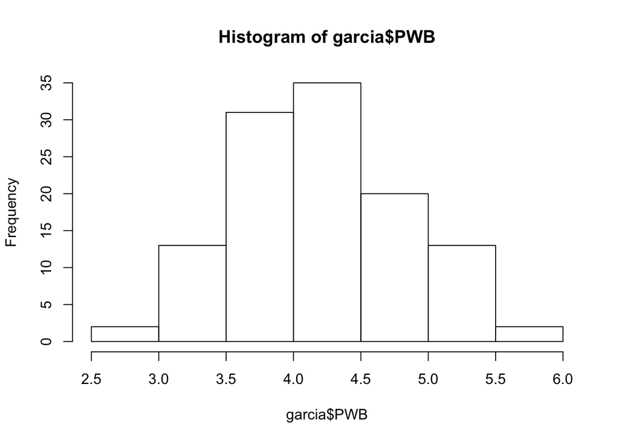

```r
hist(garcia$PWB)
```

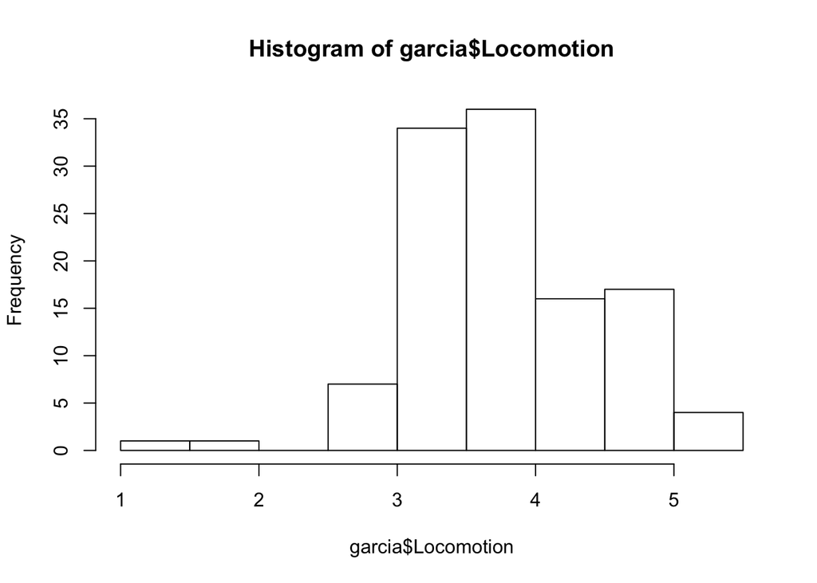

```r
hist(garcia$Locomotion)
```

## Scatter

Let’s look at how locomotion and assessment each relate to psychological well-being (PWB) First, make 2 scatter plots in ggplot with locomotion score/assessment score (respectively) on the x axis and PWB on the y axis.

*Bonus*: Make the points purple on the scatter plot for locomotion

```r
assess <- ggplot(garcia, aes(x = Assessment, y = PWB)) + geom_point()
loco <- ggplot(garcia, aes(x = Locomotion, y = PWB)) + geom_point(col = 'purple')
```

Remember to save your plots to variables!

Does it look like there’s a relationship? Let’s test this further by fitting a line to these points, with a 95% confidence interval.

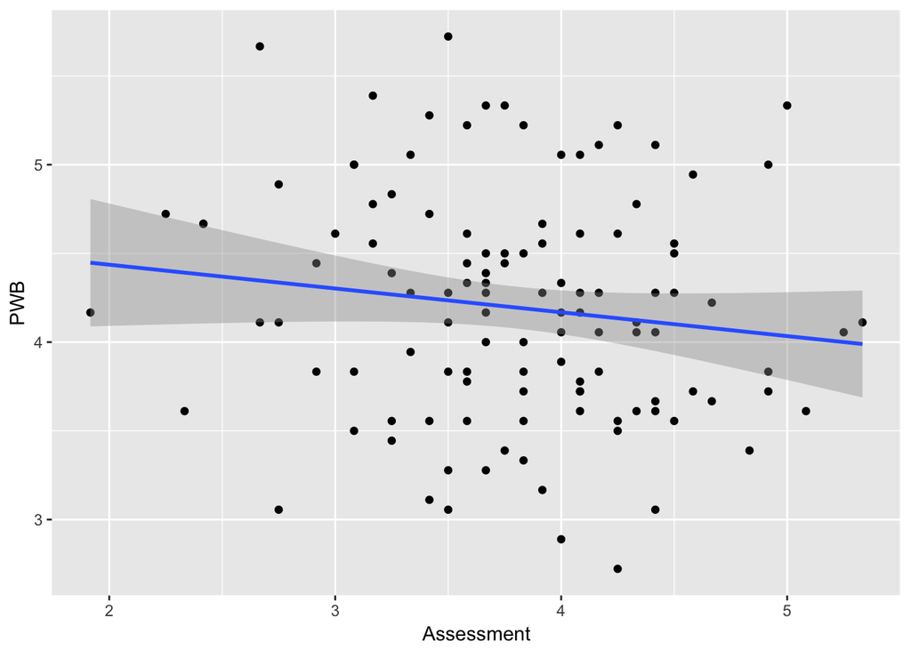

```r
assess + stat_smooth(method = 'lm')
```

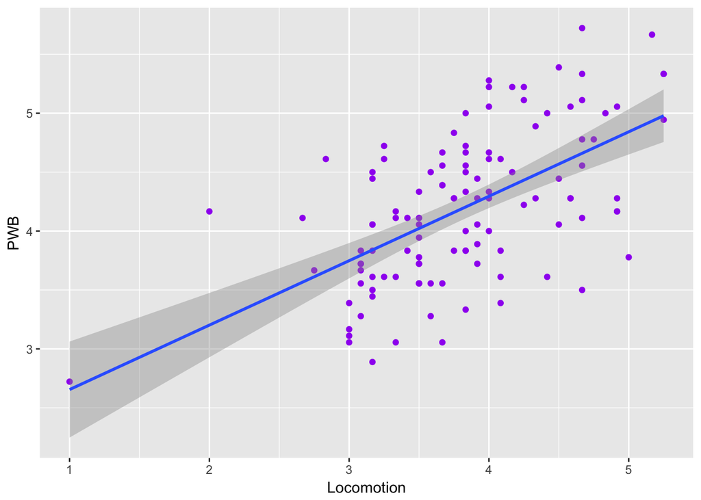

```r
loco + stat_smooth(method = 'lm')
```

Lets say we want to plot but with a 98% confidence interval instead. Modify the code from the last plots to accomplish this!

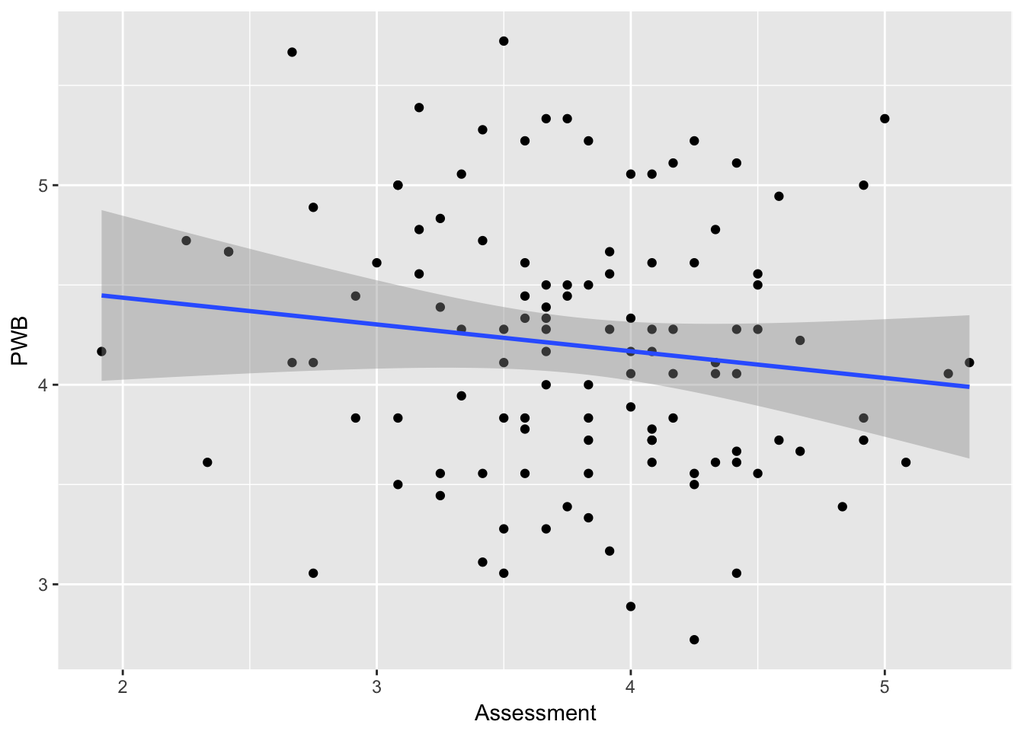

```r
assess + stat_smooth(method = 'lm', level = .98)
```

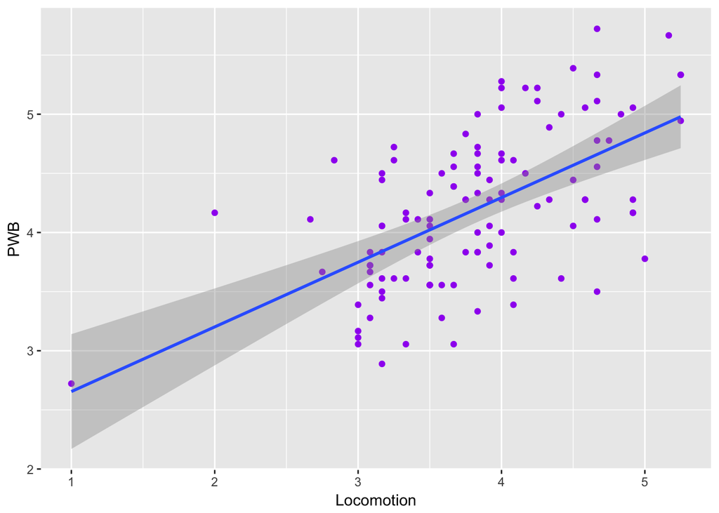

```r
loco + stat_smooth(method = 'lm', level = .98)
```

Hmm, ‘PWB’ and ‘Locomotion/Assessment’ aren’t very descriptive axis titles…can you make them something more helpful, and also title the plots?

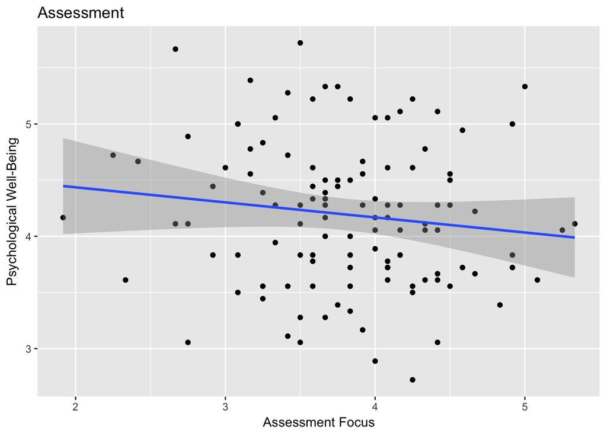

```r
assess + stat_smooth(method = 'lm', level = .98) +
  labs(x = 'Assessment Focus', y = 'Psychological Well-Being', title = 'Assessment')
```

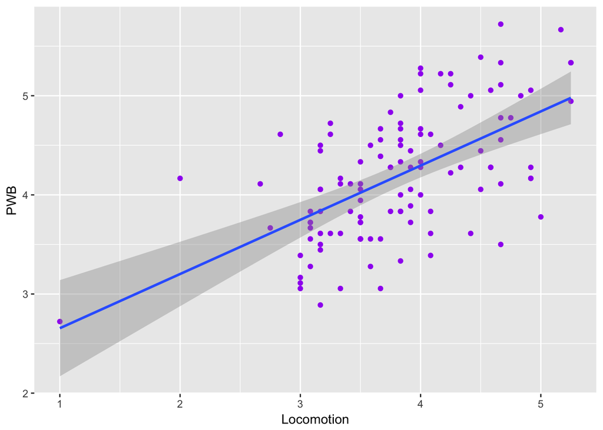

```r
loco + stat_smooth(method = 'lm', level = .98)
```

Okay, so let’s just think about locomotion for now. Maybe there’s a difference in locomoation as a function of gender. Plot a bar plot showing the average locomotion score and 95% CI for each gender. Make the bars different colors for men/women.

Remember, you might have to recode the variable to get your plot to show descriptive factor levels!

```r
require(tidyverse)
```

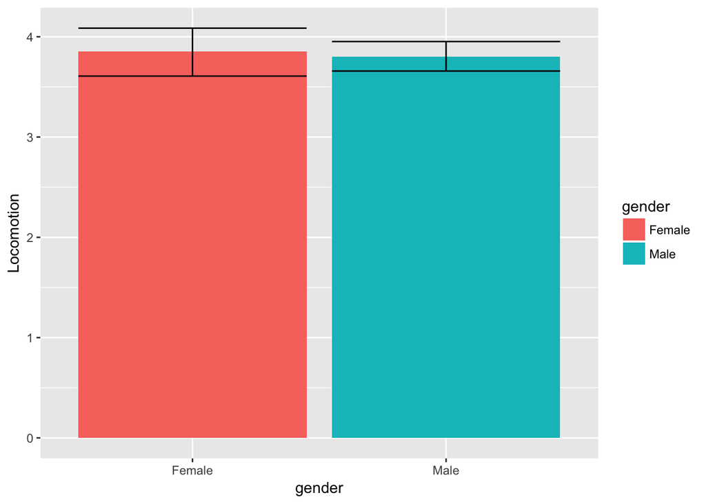

```r
garcia$gender <- as.factor(garcia$gender)
garcia$gender <- recode(garcia$gender, '1' = 'Female', '2' = 'Male')

ggplot(garcia, aes(x = gender, y= Locomotion)) + stat_summary(fun.y = 'mean', geom = 'bar', aes(fill = gender)) + stat_summary(fun.data = 'mean_cl_boot', geom = "errorbar")
```

Great! Sometimes bar plots can hide the distribution of the raw data though. Let’s see these bar plots PLUS the individual points! Use geom_jitter() to plot the points so overlaps don’t interfere with our interpretation.

*Bonus*: Make the points slightly darker than the bars so they’re visible

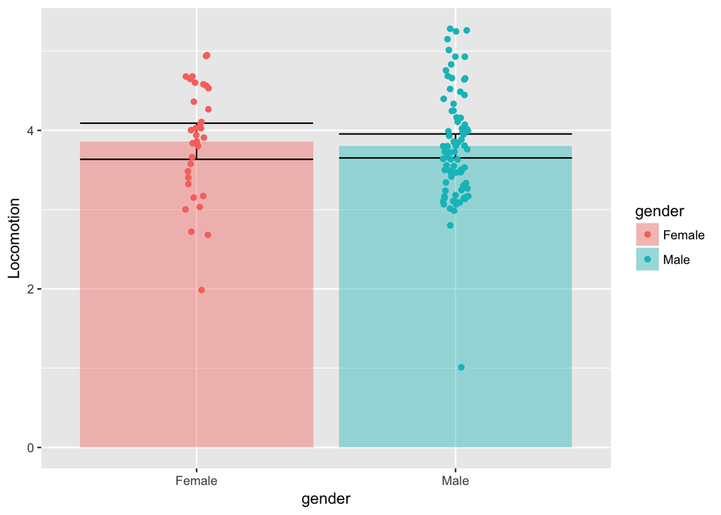

```r
ggplot(garcia, aes(x = gender, y= Locomotion)) + stat_summary(fun.y = 'mean', geom = 'bar', aes(fill = gender), alpha = .4) +
  stat_summary(fun.data = 'mean_cl_boot', geom = "errorbar") + geom_jitter(aes(col = gender), width = .05)
```

Hmm, this is getting a bit cluttered! Maybe better to just plot the mean and 95% CI, plus the jittered points. Do that using stat_summary(), and also make the jittered points smaller.

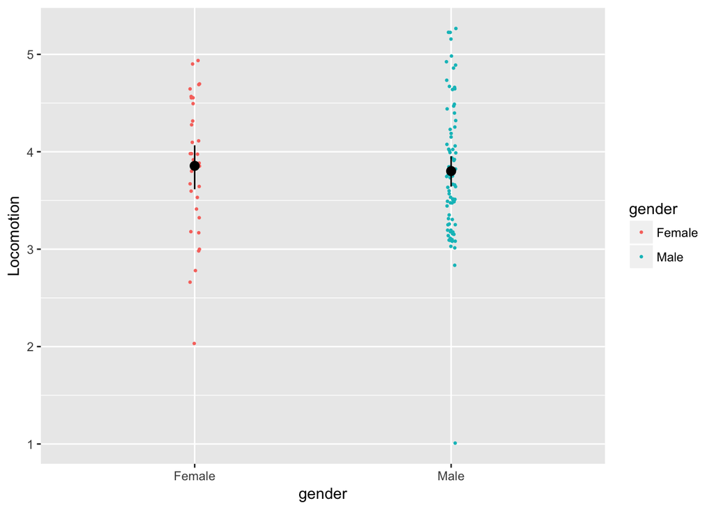

```r
ggplot(garcia, aes(x = gender, y= Locomotion))  + geom_jitter(aes(col = gender), width = .02, size = .5) + stat_summary(fun.data = 'mean_cl_boot', fun.args=list(conf.int=.95))
```

## Facetting!

Okay, so while there might not be huge gender difference in this dataset on locomotion, maybe locomotion predicts different things in males and females.

Make a scatter plot + linear regression line (with confidence interval) with locomoation on the x axis and PWB on the y axis, but this time facet by gender

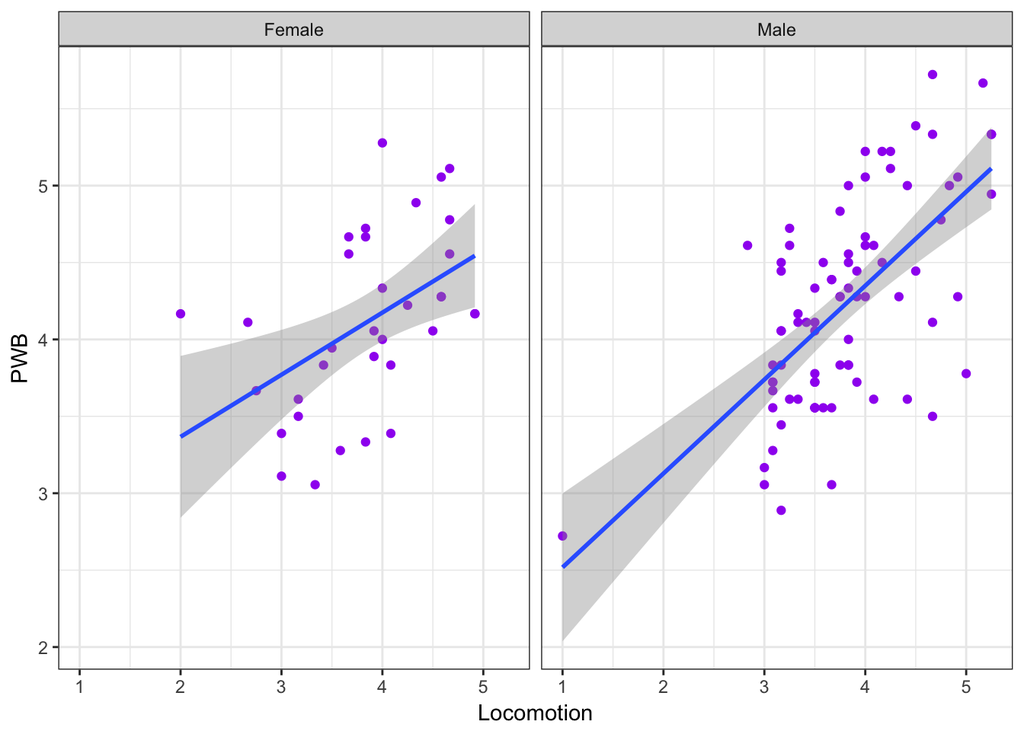

```r
loco <- ggplot(garcia, aes(x = Locomotion, y = PWB)) + geom_point(col = 'purple')

loco + stat_smooth(method = 'lm') + facet_wrap('gender') + theme_bw()
```

Okay, let’s switch it up and look at how PWB predicts academic achievement. Do this with a scatter plot. Also, let’s say we want the y axis to range the entire range of possible academic achievement scores [0,20]. How can we make ggplot do this?

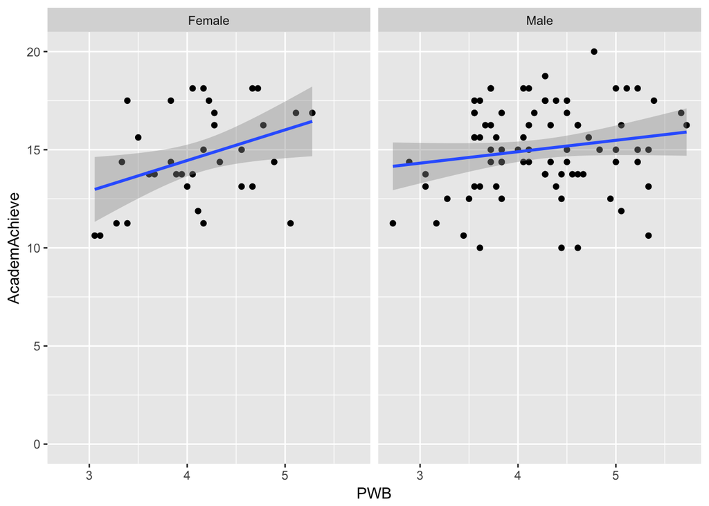

```r
ggplot(garcia, aes(x = PWB, y = AcademAchieve)) + geom_point() + ylim(0,20) + stat_smooth(method = 'lm') + facet_wrap('gender')
```

Okay, now let’s say we want to make this one look nice! Facet it by gender, give it a nice theme and informative labels!

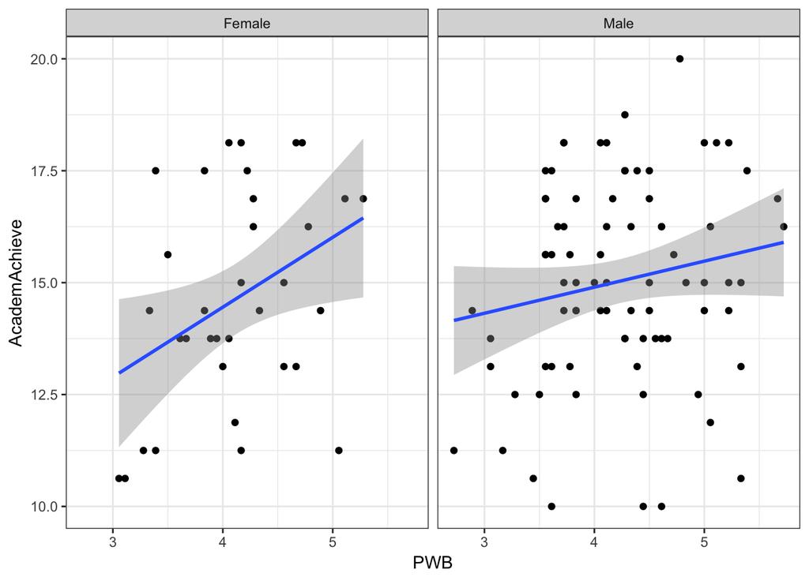

```r
ggplot(garcia, aes(x = PWB, y = AcademAchieve)) + geom_point() + stat_smooth(method = 'lm') + facet_wrap('gender') +
  theme_bw()
```

```r
  labs(x = 'Scale of Psychological Well-Being (1-6)', y = 'Academic Achievement (0-20)', title = 'Academic Achievement as a Factor of PWB/Gender')
```

```
## $x
## [1] "Scale of Psychological Well-Being (1-6)"
##
## $y
## [1] "Academic Achievement (0-20)"
##
## $title
## [1] "Academic Achievement as a Factor of PWB/Gender"
##
## attr(,"class")
## [1] "labels"
```